# 4. Compatibility

One of the main reasons Python (+Jupyter) has so many applications is its compatibility with other platforms and languages.

## HTML and the Web

In Jupyter Notebooks, you can pull in data from the web for exploration in Python. You can also pull in vizzes from other platforms, like Tableau. For example:

```python
%%HTML
<div class='tableauPlaceholder' id='viz1593489021030' style='position: relative'><noscript><a href='#'><img alt=' ' src='https:&#47;&#47;public.tableau.com&#47;static&#47;images&#47;TR&#47;TRT98WQN8&#47;1_rss.png' style='border: none' /></a></noscript><object class='tableauViz'  style='display:none;'><param name='host_url' value='https%3A%2F%2Fpublic.tableau.com%2F' /> <param name='embed_code_version' value='3' /> <param name='path' value='shared&#47;TRT98WQN8' /> <param name='toolbar' value='yes' /><param name='static_image' value='https:&#47;&#47;public.tableau.com&#47;static&#47;images&#47;TR&#47;TRT98WQN8&#47;1.png' /> <param name='animate_transition' value='yes' /><param name='display_static_image' value='yes' /><param name='display_spinner' value='yes' /><param name='display_overlay' value='yes' /><param name='display_count' value='yes' /><param name='language' value='en' /></object></div>                <script type='text/javascript'>                    var divElement = document.getElementById('viz1593489021030');                    var vizElement = divElement.getElementsByTagName('object')[0];                    vizElement.style.width='900px';vizElement.style.height='1197px';                    var scriptElement = document.createElement('script');                    scriptElement.src = 'https://public.tableau.com/javascripts/api/viz_v1.js';                    vizElement.parentNode.insertBefore(scriptElement, vizElement);                </script>
```

[figure not shown]

## SQL

You can query data in Python using SQL. Many versions of SQL are compatible with Python, but I recommend SQLite because it is serverless and self-contained. This means you do not need to install/run a special SQLite server to use a SQLite database.

```python
import pandas as pd
import sqlite3

con = sqlite3.connect("database.db")
```

```python
df = pd.read_sql_query("SELECT * FROM purchases", con)
df
```

|  | index | apples | oranges |
| --- | --- | --- | --- |
| 0 | June | 3 | 0 |
| 1 | Robert | 2 | 3 |
| 2 | Lily | 0 | 7 |
| 3 | David | 1 | 2 |

```python
df = df.set_index('index')
df
```

| index | apples | oranges |
| --- | --- | --- |
| June | 3 | 0 |
| Robert | 2 | 3 |
| Lily | 0 | 7 |
| David | 1 | 2 |

```python
df.to_csv('new_purchases.csv')
```

## MATLAB

It is possible to [read and write MATLAB files](https://cs231n.github.io/python-numpy-tutorial/#matlab-files) using the functions scipy.io.loadmat and scipy.io.savemat.

## R

It seems like, if there is a need to, you can do [just about anything](https://towardsdatascience.com/guide-to-r-and-python-in-a-single-jupyter-notebook-ff12532eb3ba) in R within the Python/Jupyter environment.

## SAS

There is a [SAS kernel](https://github.com/sassoftware/sas_kernel) in Jupyter as well. At the very least, it is possible to use Jupyter to store the input and output from SAS sessions.

## Excel

Excel integration also exists. Python can read, write, and modify workbooks using a library named openpyxl. There are Excel add-ins (xlwings, pyxll) that allow the use of Python within Excel. All seem increasingly popular.

## Local Files

We can use Python to add a border to the local image shown below.

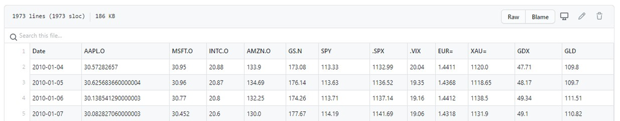

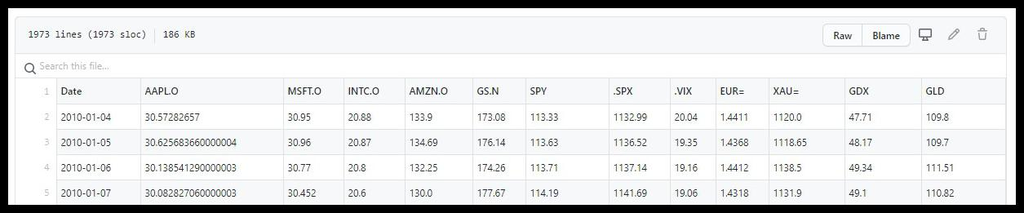

```python
# import image packages
from PIL import Image, ImageOps

# function to add border to image
def add_border(input_image, output_image, border):
    img = Image.open(input_image)

    if isinstance(border, int) or isinstance(border, tuple):
        bimg = ImageOps.expand(img, border=border)
    else:
        raise RuntimeError('Border is not an integer or tuple!')

    bimg.save(output_image)

# call function to create & save image
if __name__ == '__main__':
    in_img = 'C:/Users/natha/!Python_intro/SP500.jpg'
    add_border(in_img,
               output_image='C:/Users/natha/!Python_intro/SP500_border.jpg',
               border=(10,10))

# show image
from IPython.display import Image
Image(filename='C:/Users/natha/!Python_intro/SP500_border.jpg')
```